# Grando-8

John Grando

April 21, 2017

## Grando 8 Lab

```r
if (Sys.info()["sysname"] == "Windows") {
    setwd("~/Masters/DATA606/Week8/Lab/Lab8")
} else {
    setwd("~/Documents/Masters/DATA606/Week8/Lab/Lab8")
}
load("more/evals.RData")
require(ggplot2)
```

#### Exercise 1 - Is this an observational study or an experiment? The original research question posed in the paper is whether beauty leads directly to the differences in course evaluations. Given the study design, is it possible to answer this question as it is phrased? If not, rephrase the question.

Answer:

This is an observational study. No, since this is an observational study it is only generally sufficient to show associations between variables and should not be used to draw causal conclusions. The appropriate way to rephrase the question would be to ask: Is there a correlation between the instructor’s beauty and evaluation scores?

#### Exercise 2 - Describe the distribution of score. Is the distribution skewed? What does that tell you about how students rate courses? Is this what you expected to see? Why, or why not?

Answer:

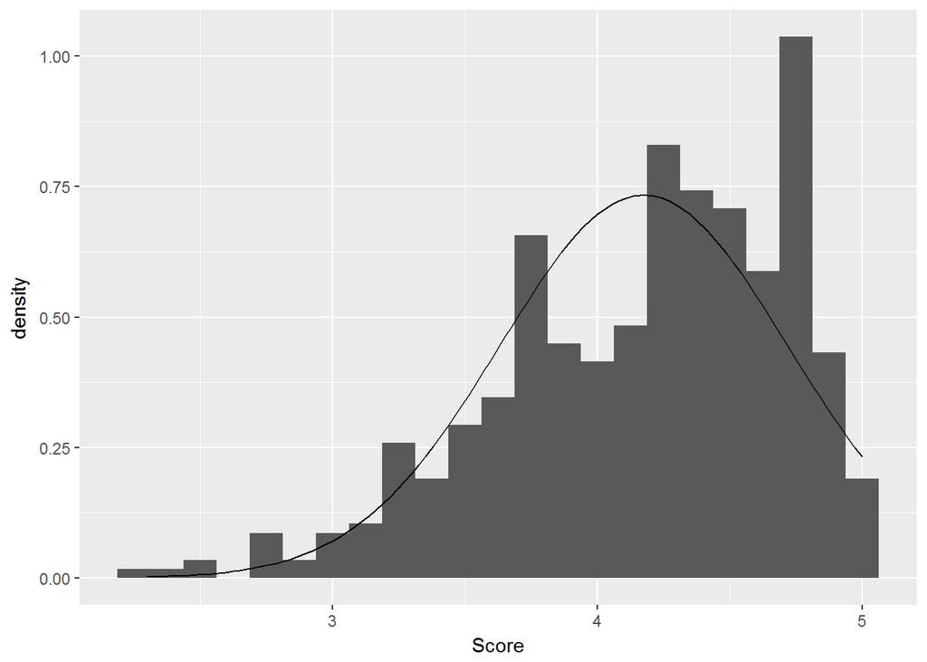

```r
ggplot(evals, aes(x = score)) + geom_histogram(binwidth = 0.125,
    position = "identity", aes(y = ..density..)) + stat_function(fun = dnorm,
    color = "black", args = list(mean = mean(evals$score), sd(evals$score))) +
    labs(x = "Score")
```

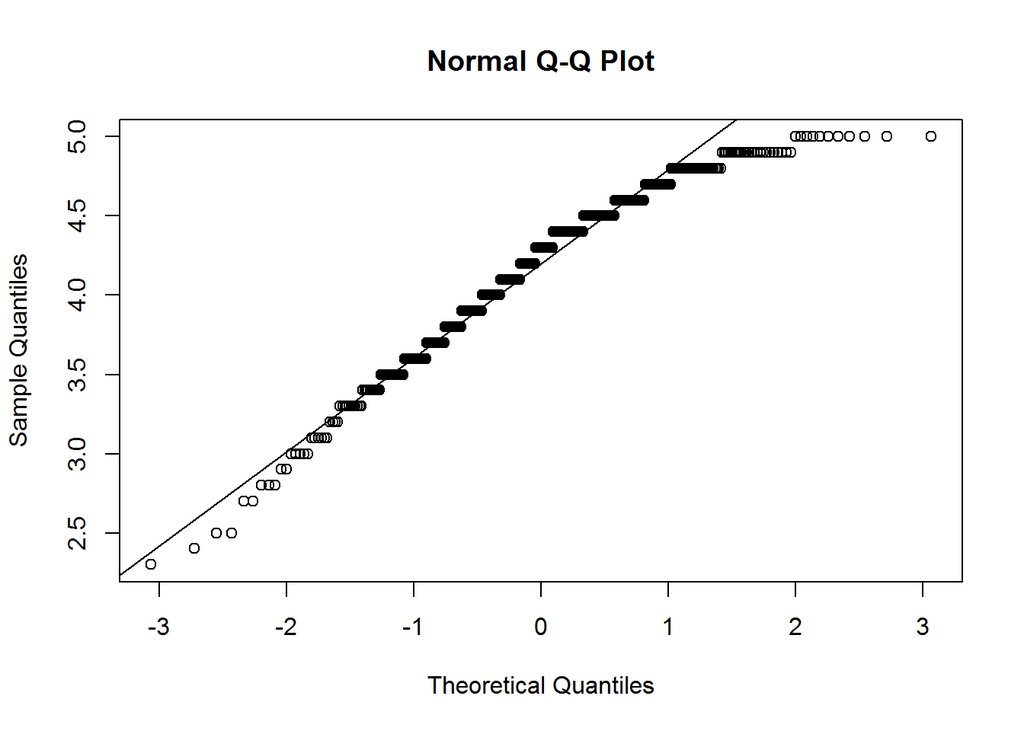

```r
qqnorm(evals$score)
qqline(evals$score)
```

The distribution has a left skew. Additionally, we can see that the residuals have a steped nature which show that there are relatively few possible unique values that were recorded. This shows that students will typically give a high score to an average class since the median is much closer to the maximum value than the minimum. It leads me to assume that if a student felt neutral towards a teacher’s performance, they generally give them a good score, possibly giving the professor the benefit of the doubt about their skills. I did expect to see something similar to this. In my experience, I find that people generally will lean towards being aggreeable in these type of surveys since it doesn’t require an argument and at least, in their minds, they would not have to strongly defend a higher score rather than a lower.

#### Exercise 3 - Excluding score, select two other variables and describe their relationship using an appropriate visualization (scatterplot, side-by-side boxplots, or mosaic plot).

Answer:

for this exercise, I will compare the percent of students who completed the evaluations against the average beauty of the professor.

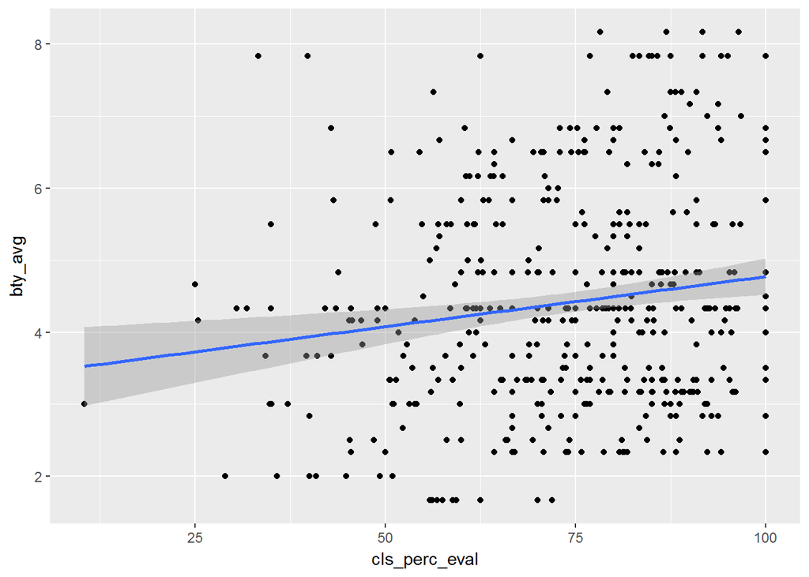

```r
ggplot(evals, aes(x = cls_perc_eval, y = bty_avg)) + geom_point() +
    geom_smooth(method = lm, fullrange = TRUE)
```

```r
e3.lm <- lm(bty_avg ~ cls_perc_eval, data = evals)
summary(e3.lm)
```

```
##
## Call:
## lm(formula = bty_avg ~ cls_perc_eval, data = evals)
##
## Residuals:
##     Min      1Q  Median      3Q     Max
## -2.7153 -1.2138 -0.1994  1.0002  3.9876
##
## Coefficients:
##               Estimate Std. Error t value Pr(>|t|)
## (Intercept)   3.381014   0.320063   10.56  < 2e-16 ***
## cls_perc_eval 0.013931   0.004196    3.32  0.00097 ***
## ---
## Signif. codes:  0 '***' 0.001 '**' 0.01 '*' 0.05 '.' 0.1 ' ' 1
##
## Residual standard error: 1.511 on 461 degrees of freedom
## Multiple R-squared:  0.02336,    Adjusted R-squared:  0.02124
## F-statistic: 11.02 on 1 and 461 DF,  p-value: 0.0009704
```

From the linear regression line, there appears to be a slightly positive slope between the percent of students who completed the evaluation and the average beauty rating of the professor. However, it does not appear that there is a good r-squared correlation with a linear model and there are not any apparent patterns for a better fit in other models (e.g. quadratic, power, etc.). It is noted that there is a significantly low p-value for the slope of the fit which suggests that the class percentage may be a statistically significant predictor of average beauty even though the correlation is low.